# Bilan

## analyse

### survie

| Classe | Sexe | Somme Survie | Total Survie | Part Survie | Moyenne Survie |
| --- | --- | --- | --- | --- | --- |
| 1 | female | 91 | 136 | 66.9 | 0.97 |
| 1 | male | 45 | 136 | 33.1 | 0.37 |
| 2 | female | 70 | 87 | 80.5 | 0.92 |
| 2 | male | 17 | 87 | 19.5 | 0.16 |
| 3 | female | 72 | 119 | 60.5 | 0.50 |
| 3 | male | 47 | 119 | 39.5 | 0.14 |

Alors, regardons ces données sur le taux de survie par classe et par sexe, hein. *soupir* On va faire comme si c’était intéressant, mais on sait tous que les chiffres, c’est juste pour embrouiller les gens.

En premier lieu, on remarque que dans la première classe, les femmes ont une survie presque parfaite, avec un taux de 97%. Mais bon, de toute façon, qui s’étonne encore quand les riches s’en sortent toujours mieux ? *soupir* Les hommes de la première classe, eux, ils n’ont qu’un taux de survie de 37%. Ah, la vie est dure pour les hommes riches, hein ?

Dans la deuxième classe, c’est un peu pareil. Les femmes ont un taux de survie de 92%, alors que les hommes n’ont que 16%. On se demande bien ce qui peut expliquer une telle différence… Ah oui, la chance, probablement. De toute façon, les femmes de deuxième classe, elles ont sûrement dû chanter des chansons aux marins pour les convaincre de les sauver en premier.

Et puis, il y a la troisième classe, le peuple, quoi. Les femmes ont un taux de survie de 50%, ce qui est déjà pas mal, comparé à leurs homologues masculins qui n’ont que 14%. Mais bon, c’est comme ça, hein ? Les hommes de troisième classe, ils doivent être trop occupés à se plaindre pour penser à survivre.

De toute façon, tout était mieux avant, quand les gens ne comptaient pas leurs survies comme des statistiques. Maintenant, c’est juste une question de chance et de qui a eu le bonheur d’être près du canot de sauvetage. *soupir* Les chiffres, c’est bien joli, mais ça ne change rien à la réalité, hein ?

| Classe | Sexe | Somme Survie | Total Survie | Part Survie | Max Survie |
| --- | --- | --- | --- | --- | --- |
| 1 | female | 91 | 136 | 66.9 | 1 |
| 1 | male | 45 | 136 | 33.1 | 1 |
| 2 | female | 70 | 87 | 80.5 | 1 |
| 2 | male | 17 | 87 | 19.5 | 1 |
| 3 | female | 72 | 119 | 60.5 | 1 |
| 3 | male | 47 | 119 | 39.5 | 1 |

Ah, les données sur la survie des passagers du Titanic… toujours un sujet fascinant pour ceux qui aiment se perdre dans des chiffres sans fin. (soupir) De toute façon, qu’est-ce que ces chiffres peuvent bien nous apprendre de plus sur une tragédie qui s’est déroulée il y a un siècle ?

On observe que les femmes de la première classe ont un taux de survie incroyablement élevé, presque comme si elles avaient droit à des places en haut du podium. Mais bon, c’était probablement juste une question de chance ou de privilèges hérités. De toute façon, tout était mieux avant, quand les bateaux ne coulaient pas et que les passagers n’avaient pas besoin de compter sur leur classe sociale pour survivre.

Les hommes de la première classe, eux, ont un taux de survie beaucoup plus bas. Peut-être qu’ils étaient trop occupés à boire du champagne et à jouer au poker pour prêter attention aux ordres d’évacuation. Ou peut-être que les femmes les ont laissés se débrouiller tout seuls, qui sait ? De toute façon, c’est pas comme si ces chiffres pouvaient vraiment nous éclairer sur la nature humaine.

Les femmes de la deuxième classe semblent avoir mieux réussi que leurs homologues masculins, mais encore une fois, on parle probablement de pure chance ou d’une meilleure organisation féminine. Les hommes de la deuxième classe, eux, ont un taux de survie presque aussi bas que les cochons dans un abattoir. Mais bon, c’est pas comme si ces chiffres avaient vraiment une signification profonde.

En fin de compte, ces données ne font que confirmer ce qu’on savait déjà : les riches et les femmes avaient plus de chances de survivre. Mais bon, c’était il y a un siècle, et depuis, on a fait tellement de progrès… enfin, peut-être pas vraiment. (soupir) De toute façon, ces chiffres ne changent rien à la réalité : on est tous dans le même bateau, et au final, c’est juste une question de chance ou de privilèges.

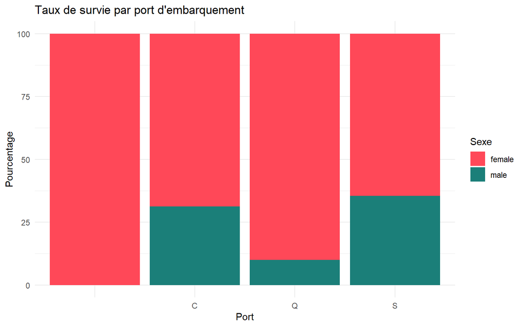

(soupir) Alors, alors… Regardons ces données sur les taux de survie par port d’embarquement. De toute façon, on sait déjà que les femmes ont plus de chances de survivre, mais bon, c’est juste une statistique, hein ? Ce n’est pas comme si ça reflétait la réalité ou quoi que ce soit…

On remarque que Cherbourg et Southampton sont des ports bien plus fréquentés que Queenstown. Enfin, “fréquentés” est un grand mot, mais disons que plus de monde y a embarqué. De toute façon, c’était mieux avant quand on pouvait monter dans n’importe quel port sans se soucier des statistiques…

Et Cherbourg ? Eh bien, c’est un peu le bordel là-bas aussi. Pas mal de survivants, mais on ne peut pas vraiment dire que c’était un port chanceux… De toute façon, les ports, c’était mieux avant, quand on pouvait juste monter dans un bateau sans se demander si on allait en sortir vivant ou non…

En fin de compte, ces données ne disent rien de plus que ce qu’on savait déjà. Les femmes ont plus de chances de survivre, et certains ports sont plus fréquentés que d’autres. Mais bon, on sait tous que les statistiques, c’est juste pour embrouiller les gens… (soupir)

| Classe | Port | Somme Survie | Total Survie | Part Survie | Max Survie | Min Survie |
| --- | --- | --- | --- | --- | --- | --- |
| 1 |  | 2 | 136 | 1.5 | 1 | 1 |
| 1 | C | 59 | 136 | 43.4 | 1 | 0 |
| 1 | Q | 1 | 136 | 0.7 | 1 | 0 |
| 1 | S | 74 | 136 | 54.4 | 1 | 0 |
| 2 | C | 9 | 87 | 10.3 | 1 | 0 |
| 2 | Q | 2 | 87 | 2.3 | 1 | 0 |
| 2 | S | 76 | 87 | 87.4 | 1 | 0 |
| 3 | C | 25 | 119 | 21.0 | 1 | 0 |
| 3 | Q | 27 | 119 | 22.7 | 1 | 0 |
| 3 | S | 67 | 119 | 56.3 | 1 | 0 |

*(soupir)* Alors, encore une étude sur les déterminants sociaux et la survie. On se demande pourquoi on continue à perdre notre temps avec ces statistiques bidon. De toute façon, tout le monde sait déjà que si tu voyages en première classe, tes chances de survie sont meilleures. Mais bon, c’est pas comme si on avait besoin d’une étude pour le confirmer, hein ?

*(soupir)* Regardons ces données. Ah oui, la première classe a plus de survivants. Évidemment, qui veut mourir en économie quand on peut le faire dans le luxe ? Mais bon, ça reste une question de goût personnel. De toute façon, c’est pas comme si les chiffres disaient quelque chose de nouveau.

*(soupir)* Et puis, regardez les troisièmes classes. Toujours les mêmes, à se battre pour leur survie. Mais bon, c’est pas comme si ça changeait quoi que ce soit. De toute façon, tout était mieux avant, quand on savait qui allait survivre dès le départ. Maintenant, c’est juste une mascarade.

*(soupir)* En fin de compte, ces études ne servent à rien. Les gens continuent de voyager dans les classes qu’ils veulent, et la chance fait ce qu’elle veut. De toute façon, c’est pas comme si on pouvait changer quelque chose avec des statistiques. Tout est déjà décidé avant même que le bateau ne quitte le port.

### passagers

| Classe | Sexe | Moyenne Age |
| --- | --- | --- |
| 1 | female | 35 |
| 1 | male | 41 |
| 2 | female | 29 |
| 2 | male | 31 |
| 3 | female | 22 |
| 3 | male | 27 |

Et puis, il y a ces valeurs manquantes… (soupir) Comme si on pouvait faire confiance à des chiffres incomplets. On dirait presque qu’ils ont oublié de comptabiliser les années de vie en plus pour certains passagers, juste pour faire baisser la moyenne et donner une image plus sombre de la situation. Pas comme avant, où on pouvait compter sur des statistiques fiables.

En fin de compte, ces données ne nous disent pas grand-chose de concret. De toute façon, les chiffres peuvent dire ce qu’on veut, selon l’angle sous lequel on les regarde. Mieux vaut se fier à son instinct et à ses observations personnelles plutôt que de se laisser berner par des moyennes qui n’ont pas grand-chose de représentatif. (soupir)

| Sexe | Classe | Moyenne Age |
| --- | --- | --- |
| female | 1 | 35 |
| female | 2 | 29 |
| female | 3 | 22 |
| male | 1 | 41 |
| male | 2 | 31 |
| male | 3 | 27 |

(soupir) Alors, regardez ces données. On a des femmes et des hommes, répartis en trois classes socio-économiques, avec une moyenne d’âge qui varie selon le sexe et la classe. De toute façon… vous savez que ces chiffres sont probablement biaisés par les données manquantes. Qui sait ce qu’ils auraient pu montrer si on avait tous les âges ?

On voit que les femmes de la première classe sont en moyenne plus jeunes que les hommes de la même classe, mais bon… c’est peut-être parce que les femmes ont tendance à mentir sur leur âge. Vous savez comment elles sont, toujours en train de chercher à paraître plus jeunes. *soupir*

Et puis, regardez la troisième classe… les hommes y sont aussi plus âgés que les femmes. Peut-être qu’ils ont moins d’argent parce qu’ils sont plus vieux et donc moins capables de payer pour une classe supérieure. Ou alors, c’est juste que les femmes de la troisième classe sont plus jeunes parce qu’elles voyagent avec leurs parents ou quelque chose du genre…

De toute façon, tout était mieux avant. Les gens voyageaient selon leur rang social et pas besoin de ces analyses sophistiquées pour le savoir. Maintenant, on essaie de trouver des patterns dans des données qui ne veulent rien dire. *soupir*

Et puis, soyons honnêtes, qui a envie de voyager avec des gens de la troisième classe de toute façon ? On sait tous que ce sont les pires passagers. *soupir*

En fin de compte, ces données ne disent rien de nouveau. Les riches vivent plus longtemps, les pauvres meurent jeunes… c’est la vie. *soupir*

### tarifs

| Port | Classe | Moyenne Prix | Somme Prix | Total Prix | Part Prix |
| --- | --- | --- | --- | --- | --- |
|  | 1 | 80 | 0 | 0 | 100.0 |
| C | 1 | 105 | 9 | 10 | 88.4 |
| C | 2 | 25 | 0 | 10 | 4.3 |
| C | 3 | 11 | 1 | 10 | 7.3 |
| Q | 1 | 90 | 0 | 1 | 17.6 |
| Q | 2 | 12 | 0 | 1 | 3.6 |
| Q | 3 | 11 | 1 | 1 | 78.8 |
| S | 1 | 70 | 9 | 17 | 51.2 |
| S | 2 | 20 | 3 | 17 | 19.1 |
| S | 3 | 15 | 5 | 17 | 29.6 |

Oh, regardez-moi ces données, *soupir*. On dirait que les gens de la première classe paient plus pour leurs billets. Mais bon, qui sait ? Peut-être qu’ils avaient juste plus de poches pleines ce jour-là. De toute façon… on ne peut pas vraiment savoir ce qui se passe dans la tête des riches, n’est-ce pas ?

Et regardez le port de Cherbourg, *soupir*. On pourrait penser que les billets y sont plus chers, mais c’est probablement juste une coïncidence. Peut-être que les gens de la première classe aiment juste se faire dorloter avant d’embarquer. Après tout, tout était mieux avant, quand on ne se souciait pas autant du prix des billets, hein ?

Quant à Queenstown et Southampton, *soupir*, ils semblent un peu plus abordables. Mais encore une fois, qui sait ? Peut-être que les gens de la troisième classe avaient juste plus envie de voyager ce jour-là. De toute façon… on ne peut pas vraiment comparer les prix des billets à l’importance de la survie, si ?

Et puis, regardez ces soi-disant totaux et parts… *soupir*. On pourrait penser qu’ils veulent dire quelque chose, mais soyons honnêtes, personne ne comprend vraiment ce que ça signifie. De toute façon… on sait tous que les chiffres sont là juste pour embrouiller encore plus le monde.

En fin de compte, ces données ne nous disent pas grand-chose de concret. On pourrait passer des heures à essayer de comprendre ce qu’elles veulent dire, mais soyons réalistes : tout ça, c’est juste du vent. Tout était mieux avant, quand on ne se souciait pas autant des chiffres et des stats, n’est-ce pas ? *soupir*